# Lab7

Pedro Avila, Javier Benitez, Brandon Rivera

2026-04-18

## Pasaporte

### Preparación de datos

```r
library(dplyr)
```

```r
library(ggplot2)
library(caret)
load("datasets/listings.RData")

listings$price <- as.numeric(gsub("[$,]", "", listings$price))
listings <- listings |> filter(!is.na(price), price > 0, price < 1000)

features <- c("accommodates", "bathrooms", "bedrooms", "beds",
              "minimum_nights", "number_of_reviews", "review_scores_rating")

listings_clean <- listings |>
  select(all_of(features), price) |>
  na.omit()

q33 <- quantile(listings_clean$price, 0.33)
q66 <- quantile(listings_clean$price, 0.66)

listings_clean$price_cat <- cut(
  listings_clean$price,
  breaks = c(-Inf, q33, q66, Inf),
  labels = c("barata", "media", "cara")
)
```

1. Use los mismos conjuntos de entrenamiento y prueba de las hojas de trabajo pasadas para probar el algoritmo.

```r
set.seed(42)
idx   <- createDataPartition(listings_clean$price, p = 0.7, list = FALSE)
train <- listings_clean[idx, ]
test  <- listings_clean[-idx, ]
```

2. Explore los datos y explique las transformaciones que debe hacerle para generar un modelo de máquinas vectoriales de soporte.
3. Use como variable respuesta la variable categórica que especifica si la casa es barata, media o cara.

```r
summary(train)
```

```
##   accommodates      bathrooms         bedrooms           beds
##  Min.   : 1.000   Min.   : 0.000   Min.   : 0.000   Min.   : 0.000
##  1st Qu.: 2.000   1st Qu.: 1.000   1st Qu.: 1.000   1st Qu.: 1.000
##  Median : 4.000   Median : 1.000   Median : 1.000   Median : 2.000
##  Mean   : 4.689   Mean   : 1.536   Mean   : 1.734   Mean   : 2.575
##  3rd Qu.: 6.000   3rd Qu.: 2.000   3rd Qu.: 2.000   3rd Qu.: 3.000
##  Max.   :16.000   Max.   :13.000   Max.   :48.000   Max.   :23.000
##  minimum_nights    number_of_reviews review_scores_rating     price
##  Min.   :  1.000   Min.   :   1.00   Min.   :1.000        Min.   :  8.0
##  1st Qu.:  1.000   1st Qu.:   7.00   1st Qu.:4.750        1st Qu.:114.0
##  Median :  2.000   Median :  28.00   Median :4.890        Median :178.0
##  Mean   :  7.592   Mean   :  67.93   Mean   :4.801        Mean   :228.4
##  3rd Qu.:  4.000   3rd Qu.:  85.00   3rd Qu.:4.990        3rd Qu.:285.0
##  Max.   :365.000   Max.   :1592.00   Max.   :5.000        Max.   :999.0
##   price_cat
##  barata:14030
##  media :14021
##  cara  :14364
##
##
##
```

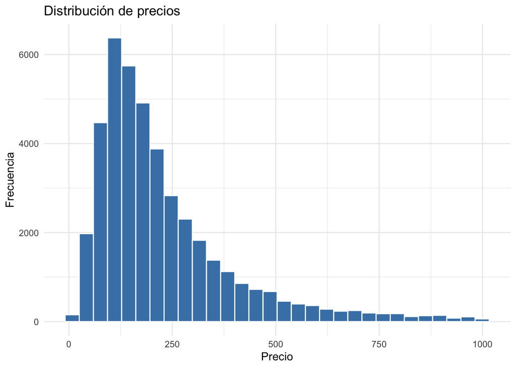

```r
ggplot(train, aes(x = price)) +
  geom_histogram(bins = 30, fill = "steelblue", color = "white") +
  labs(title = "Distribución de precios", x = "Precio", y = "Frecuencia") +
  theme_minimal()
```

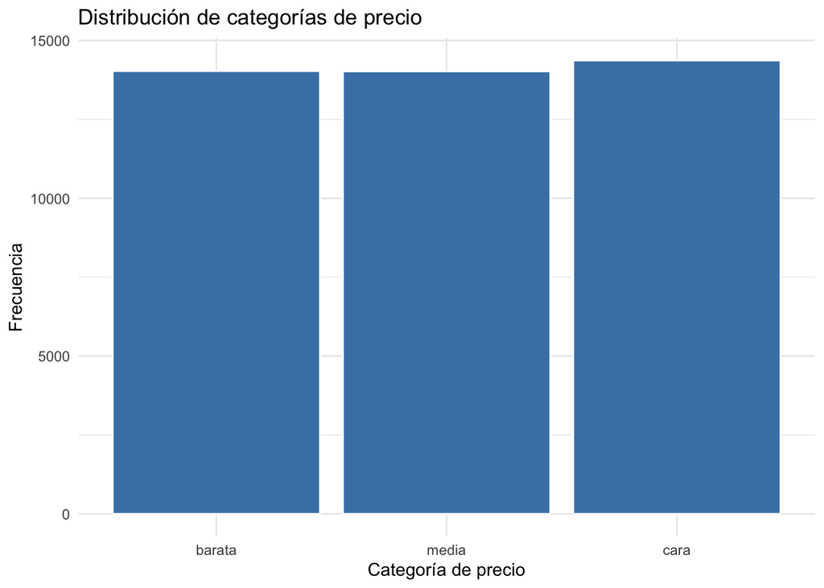

```r
ggplot(train, aes(x = price_cat)) +
  geom_bar(fill = "steelblue", color = "white") +
  labs(title = "Distribución de categorías de precio", x = "Categoría de precio", y = "Frecuencia") +
  theme_minimal()
```

Las SVM calculan distancias (o productos punto) entre puntos en el espacio de características, por lo que variables con escalas muy distintas distorsionan ese cálculo: `minimum_nights` (rango 1–365) y `number_of_reviews` (rango 1–1592) dominarían sobre `review_scores_rating` (rango 1–5) sin normalización. Además, ambas variables presentan fuerte sesgo positivo (media << máximo), lo que concentra la mayoría de los puntos en valores bajos y genera outliers que dificultan encontrar el hiperplano óptimo. Por ello se aplican dos transformaciones: (1) **logaritmo** en las variables sesgadas para comprimir la cola derecha, y (2) **estandarización z-score** (media 0, desviación 1) en todos los predictores para igualar la influencia de cada variable en el kernel. Las clases (`price_cat`) ya están balanceadas (≈14k observaciones cada una), por lo que no se requiere re-muestreo.

```r
train_svm <- train
test_svm  <- test

train_svm$minimum_nights    <- log1p(train_svm$minimum_nights)
train_svm$number_of_reviews <- log1p(train_svm$number_of_reviews)
test_svm$minimum_nights     <- log1p(test_svm$minimum_nights)
test_svm$number_of_reviews  <- log1p(test_svm$number_of_reviews)

pre_proc <- preProcess(train_svm[, features], method = c("center", "scale"))
train_svm[, features] <- predict(pre_proc, train_svm[, features])
test_svm[, features]  <- predict(pre_proc, test_svm[, features])

train_svm$price_cat <- factor(train_svm$price_cat)
test_svm$price_cat  <- factor(test_svm$price_cat)

summary(train_svm[, features])
```

```
##   accommodates       bathrooms          bedrooms            beds
##  Min.   :-1.3275   Min.   :-1.9195   Min.   :-1.4192   Min.   :-1.4239
##  1st Qu.:-0.9676   1st Qu.:-0.6701   1st Qu.:-0.6009   1st Qu.:-0.8708
##  Median :-0.2479   Median :-0.6701   Median :-0.6009   Median :-0.3177
##  Mean   : 0.0000   Mean   : 0.0000   Mean   : 0.0000   Mean   : 0.0000
##  3rd Qu.: 0.4718   3rd Qu.: 0.5794   3rd Qu.: 0.2174   3rd Qu.: 0.2353
##  Max.   : 4.0702   Max.   :14.3233   Max.   :37.8598   Max.   :11.2965
##  minimum_nights    number_of_reviews  review_scores_rating
##  Min.   :-0.8075   Min.   :-1.72728   Min.   :-11.7878
##  1st Qu.:-0.8075   1st Qu.:-0.80020   1st Qu.: -0.1593
##  Median :-0.3854   Median : 0.06104   Median :  0.2748
##  Mean   : 0.0000   Mean   : 0.00000   Mean   :  0.0000
##  3rd Qu.: 0.1464   3rd Qu.: 0.78800   3rd Qu.:  0.5849
##  Max.   : 4.6153   Max.   : 2.74007   Max.   :  0.6159
```

Tras la transformación todas las variables tienen media ≈ 0 y desviación estándar ≈ 1, eliminando la ventaja artificial de las variables de mayor magnitud. El parámetro de escala se aprende **solo del conjunto de entrenamiento** y se aplica al de prueba para evitar fuga de información.

4. Genere varios (más de 2) modelos de SVM con diferentes kernels y distintos valores en los parámetros c, gamma (circular) y d (en caso de que utilice el polinomial). Puede tunear el modelo de forma automática siempre que explique los resultados
5. Use los modelos para predecir el valor de la variable respuesta
6. Haga las matrices de confusión respectivas.
7. Analice si los modelos están sobre ajustados o desajustados. ¿Qué puede hacer para manejar el sobreajuste o desajuste?